# RSV (ABRYSVO) - Muscular weakness

OpenSourcePV

Data Lock Point: 2024_01_26

# 1 Quantitative Signal status

## 1.1 Disproportionality

The vaccine-event combination “RSV (ABRYSVO) - Muscular weakness” was **a signal of disproportionate reporting** with an EB05 value of 2.02.

The threshold for being flagged as a signal of disproportionate reporting is an EB05>=2 meaning that there there is a 95% probability that the reporting of Muscular weakness was at least twice post exposure to RSV (ABRYSVO) than post all vaccines [1]. Under the assumption of no causality between RSV (ABRYSVO) and Muscular weakness and no bias it would have been expected to observe an EBGM of 1.

It means that the quantified causality criterion of strength of association is **met**.

*It is to be noted that the nature of the spontaneous report does not provide reliable estimates of the strength of association (whatever the choice of the disproportionality method) and that some reporting bias or difference in demographic characteristics might explain the (un)observed disproportion*.

## 1.2 Time-to-onset

The vaccine-event combination “RSV (ABRYSVO) - Muscular weakness” was **not a signal of unexpected time-to-onset distribution** with a p-value of the two-sample Kolmogorov-Smirnov test being 0.7719288 and distance between the two empirical cumulative distributions being of 13.2665643%.

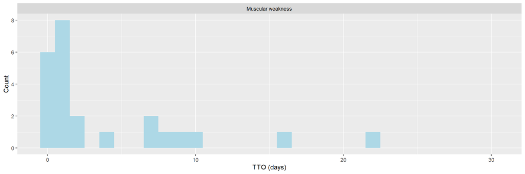

The TTO signal detection method tests if the distribution of Muscular weakness post RSV (ABRYSVO) is significantly different from the distribution of Muscular weakness post other vaccines using a two-sample Kolmogorov-Smirnov test [2]. The threshold for being flagged as a signal of unexpected time-to-onset distribution is a P-value <0.001 and a distance between the two empirical distributions larger than 20%. Under the assumption of no causality and no bias, it would have been expected that the time-to-onset distribution for “Muscular weakness” would have been the same post RSV (ABRYSVO) than post other vaccines.

It means that the quantified causality criterion of temporality is **not met**.

*It is to be noted that the nature of the spontaneous report does not provide reliable estimates of the temporal relationship between the exposure and the occurrence of the events as there is the reporting bias over time: the latter the event occurs after exposure, the less chance it has to be reported. Other biases could distort the reported time-to-onset distribution (media attention, etc.)*

## 1.3 Overall

Based on the screening of the Empirical Bayes Geometric Mean (EBGM) and the screening of the time-to-onset distribution,the vaccine-event combination “RSV (ABRYSVO) - Muscular weakness” is **considered as quantitative signal**.

# 2 Signal History

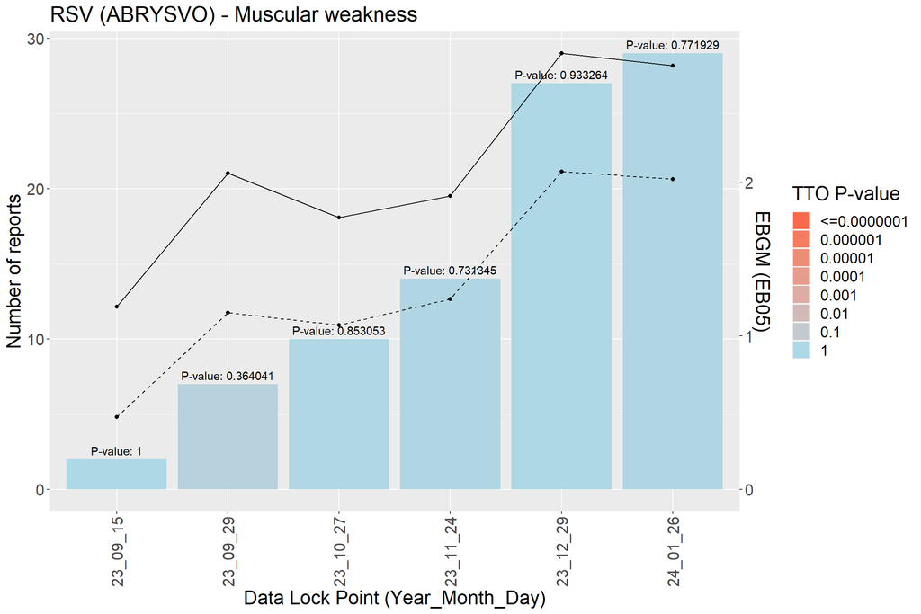

# 3 Case series

## 3.1 Seriousness

A total of 29 reports of Muscular weakness were received post exposure to RSV (ABRYSVO). Among them:

- 0 (0.0 %) were fatal cases.
- 3 (10.3 %) were life threatening cases.
- 8 (27.6 %) were hospitalized cases.
- 0 (0.0 %) were emergency room cases.
- 7 (24.1 %) were cases with disabilies.

2 new cases were received since last data refresh.

## 3.2 Demographic characteristics

29 cases of Muscular weakness post RSV (ABRYSVO) were reported in VAERS:

- Among them, there were 19 (65.5%) female cases and 10 (34.5%) male cases while the overall female:male ratio is 62:28%.
- The mean (median) age for patients presenting symptoms of Muscular weakness was 74 (72) years while the overall mean (median) age was 69 (72) years.
- The top 5 contributing US states for patients presenting symptoms of Muscular weakness were PA ( 13.8 %) , AZ ( 10.3 %) , IL ( 10.3 %) , AL ( 6.9 %) , MN ( 6.9 %) while overall the top 5 of contributing US states are NA ( 12.4 %) , CA ( 6.4 %) , NY ( 5.2 %) , OH ( 5.2 %) , PA ( 5 %)

# 4 Manufacturing

# 5 Listing of the cases

Narratives can be made visible clicking on the ⊕ symbol.

|  | VAERS ID | Sex/Age (Years) | Receipt Date | Seriousness status | List of symptoms | New | SYMPTOM_TEXT |
| --- | --- | --- | --- | --- | --- | --- | --- |
| &oplus; | 2730830 | M/67 | 01/09/2024 | Life threatening &amp; Hospitalized | Blood test, Constipation, CSF protein increased, CSF test abnormal, Enzyme level increased, Guillain-Barre syndrome, Magnetic resonance imaging head, Muscular weakness, Plasmapheresis, Sensory loss, V… | Yes | He got his vaccine had a small pain where he got the vaccine no AE until he started loosing the sensation in his legs He called his doctor that he thought it was a sciatic nerve They felt it was somet… |
| &oplus; | 2738290 | M/73 | 01/23/2024 | Life threatening &amp; Hospitalized | Acute respiratory failure, Asthenia, Cough, Endotracheal intubation, Guillain-Barre syndrome, Immunoglobulin therapy, Laboratory test normal, Lumbar puncture normal, Muscular weakness, Plasmapheresis,… | Yes | Admitted to the hospital 1 13 with leg weakness that started on 1 12 This rapidly progressed to ascending weakness that progressed to acute respiratory failure was intubated 1 16 Underwent lumbar punc… |
| &oplus; | 2678792 | F/72 | 09/01/2023 |  | Gait disturbance, Muscular weakness, Paraesthesia | No | 8 30 23 after waking up 730 am tingling on the entire sole of left foot tingling on left leg from foot to the knee muscle weakness lower right leg up to the knee felt weak Symptoms maintained during t… |
| &oplus; | 2682052 | F/71 | 09/14/2023 |  | Arthralgia, Arthritis, Arthropathy, Burning sensation, Condition aggravated, Muscular weakness, Pain in extremity, Paraesthesia, Sleep disorder | No | She got her vaccines she was fine when she first got it She came home made and had dinner was watching TV and went to bed around 900 She woke up around 345 AM with really bad pain in her hands from he… |
| &oplus; | 2682555 | M/85 | 09/15/2023 |  | Asthenia, Dizziness, Fatigue, Headache, Listless, Muscular weakness | No | He got his vaccine when he was picking up a prescription and he got it then went home and had dinner around 600 He then felt light headed and dizzy He started to get a slight headache which he never g… |
| &oplus; | 2683132 | F/69 | 09/18/2023 |  | Hypotonia, Muscular weakness | No | patient stated on Sunday on four separate occasions her left hand went flacid ie she was unable to move it She had gotten RSV and flu shot both in her left arm RPh had recommended one in each are but … |
| &oplus; | 2684494 | M/84 | 09/21/2023 |  | Gait inability, Muscular weakness | No | bilateral lower extremity weakness unable to ambulate |
| &oplus; | 2684666 | M/70 | 09/21/2023 |  | Dizziness, Dysstasia, Hypertension, Mobility decreased, Muscular weakness | No | High blood pressure 177 111 weakness in legs and arms dizziness cant get up from sitting position or laying position if on the floor cant get up from that position Outcome most adverse events ended ab… |
| &oplus; | 2687658 | F/67 | 09/27/2023 |  | Chest pain, Dyspnoea, Heart rate increased, Heart rate irregular, Muscular weakness | No | Rapid and irregular heartbeat shortness of breath weakness in legs on 9 8 2023 On 9 10 2023 9 11 2023 I had intermittent chest pain |
| &oplus; | 2689332 | F/81 | 10/02/2023 | Hospitalized | Dehydration, Muscular weakness, Urinary tract infection | No | Patient received influenza TDaP Pneumococcal COVID 19 and Zostavax vaccines on site at her assisted living facility She is not aware of the manufacturer or brands |

[output cut: 19 more lines]

# 6 Disclaimer

This analysis is exploratory only and authors cannot be held responsible for any decision made using these data. It is important to distinguish quantitative signals such as disproportionate reporting, unexpected time-to-onset patterns or cluster from safety signals. Only a qualitative review using multiple data source (literature, clinical trials, etc.) and multiple causality criteria assessment could qualify quantitative signals into safety signals.

# 7 References

[1] Dumouchel W. Bayesian data mining in large frequency tables, with an application to the FDA spontaneous reporting system. Am Stat 1999; 53: 177–190.

[2] Van Holle L et al, Using time‐to‐onset for detecting safety signals in spontaneous reports of adverse events following immunization: a proof-of-concept study. Pharmacoepidemiology and Drug Safety 21 (6), 603-610.